# Learn to analyze flow cytometry data in R

```r
require(tidyverse)
require(flowCore)
require(flowClust)
require(open)
require(ggcyto)
require(gridExtra)
```

# Goal

Follow Metzger *et al.* 2015 (PMID: 25778704) to learn how to analyze flow cytometry data in R

To do so, I have the following tasks:

- Learn how to load fcs files into R and how to access the data and parameters therein
- Learn how to read multiple fcs files for an entire experiment as a flow set object and associate the sample information with it
- Learn how to make commonly used diagnostic plots like the incidence density plot and histograms
- Learn how to filter out unwanted events using histogram and polygonal gates
- Learn how to use FlowClust to automatically cluster cell populations
- Determine the need to correct for cell size
- Examine covariates like position on plates and day effects

# Data

- From 2021-04-02 experiment conducted by Jia and Lindsey to test the chimeric Pho4 with *PHO5p*-RFP strains
- From 2021-08-26 to 28 experiment conducted by Lindsey to test the covariates such as plate position

# Tutorial

## FlowCore

[reference](https://www.bioconductor.org/packages/release/bioc/vignettes/flowCore/inst/doc/HowTo-flowCore.pdf)

```r
file.name <- system.file("extdata","0877408774.B08", package="flowCore")
x <- read.FCS(file.name, transformation=FALSE)
summary(x)
```

```r
keyword(x, paste0("$P",1:4,"E"))
summary(read.FCS(file.name))
```

```r
fcs.dir <- system.file("extdata",
                       "compdata",
                       "data",
                       package="flowCore")
frames <- lapply(dir(fcs.dir, full.names=TRUE), read.FCS)
fs <- as(frames, "flowSet")
fs
sampleNames(fs)
```

```r
names(frames) <- sapply(frames, keyword, "SAMPLE ID")
fs <- as(frames, "flowSet")
fs
sampleNames(fs)
```

```r
phenoData(fs)$Filename <- fsApply(fs, keyword, "$FIL")
pData(phenoData(fs))
```

```r
fs <- read.flowSet(path = fcs.dir)
```

```r
x <- read.FCS(file.name, column.pattern = "-H")
ggcyto(x, aes(x = `FL1-H`, `FL2-H`)) + geom_hex(bins = 128)
autoplot(x, "FL1-H")
```

# Analysis

## Import data and edit the meta data

```r
data.path = "data/FCS-files/20210402-LS-JZ-chimeric-Pho4/"
fs <- read.flowSet(path = data.path, transformation = FALSE,  # the original values are already linearized.
                   emptyValue = FALSE,  alter.names = TRUE,   # change parameter names to R format
                   column.pattern = ".H|FSC|SSC") # only load the height variables for the fluorescent parameters
```

Metadata

```r
sample <- read_csv("data/sample-list/20210402-LS-JZ-chimeric-Pho4-sample.csv")
df <- data.frame(name = sampleNames(fs)) %>% mutate(strain = str_split(name, "-", simplify = TRUE)[,1]) %>% left_join(sample, by = c("strain" = "Sample"))
rownames(df) <- df$name
metaData <- data.frame(labelDescription = c("filename", "sample name", "experimenter", "Pho4 source", "Fluorescent protein tag", "Pho4 chimera genotype", "Pho2 present", "PHO5pr reporter location"))
pData(fs) <- df
varMetadata(fs) <- metaData
```

## EDA

The code below demonstrates how to subset a flowSet, how to apply logicle (or other) transformations in ggcyto() (not on the original dataset)

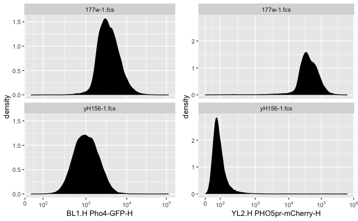

```r
p1 <- autoplot(fs[sampleNames(fs) %in% c("yH156-1.fcs","177w-1.fcs")], "BL1.H") + scale_x_logicle() + facet_wrap(~name, nrow = 2)
p2 <- autoplot(fs[sampleNames(fs) %in% c("yH156-1.fcs","177w-1.fcs")], "YL2.H") + scale_x_logicle() + facet_wrap(~name, nrow = 2)
grid.arrange(as.ggplot(p1), as.ggplot(p2), ncol = 2)
```

- Pick out two examples, one positive (177) and one negative (156) for both the GFP and RFP channels.

## Gating

Let’s first define a gate and visualize it in a plot before adding it to a GatingSet.

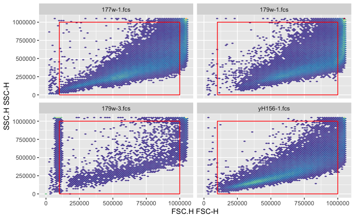

```r
outlier.gate <- rectangleGate(filterId = "-outlier", "FSC.H" = c(1e5, 1e6), "SSC.H" = c(1e2, 1e6))
ggcyto(fs[sampleNames(fs) %in% c("yH156-1.fcs", "177w-1.fcs", "179w-1.fcs", "179w-3.fcs")], aes(x = FSC.H, y = SSC.H), subset = "root") +
  geom_hex(bins = 64) + geom_gate(outlier.gate) + facet_wrap(~name, ncol = 2)# + ggcyto_par_set(limits = "instrument")
```

Add this gate to the GatingSet

```r
gs <- GatingSet(fs) # create a GatingSet
gs_pop_add(gs, outlier.gate, parent = "root")
```

```
[1] 2
```

```r
recompute(gs)
```

```
done!
```

Let’s examine how this gate intersected with the FSC.H vs FSC.W plot (for singlets)

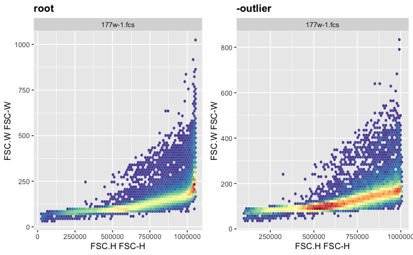

```r
p1 <- ggcyto(gs[[1]], aes(x = FSC.H, y = FSC.W), subset = "root") + geom_hex(bins = 64)
p2 <- ggcyto(gs[[1]], aes(x = FSC.H, y = FSC.W), subset = "-outlier") + geom_hex(bins = 64)
grid.arrange(as.ggplot(p1), as.ggplot(p2), ncol = 2)
```

### Singlet

Next let’s remove multiplets on FSC.H vs FSC.W. To do this, we could either manually set up a polygon gate, or use the automatic clustering function provided by the `flowClust` package. Note that in the original implementation, the `flowClust()` function or the `tmixFilter()` version that was supposed to allow for integration with the `flowCore` package, both were designed with different downstream actions in mind than what I want to do here (visualize with `ggcyto() + geom_gate()`). The `openCyto` package written by the same group of authors who created `flowClust` and `ggcyto` has a helper function to make this possible. See [this post](https://support.bioconductor.org/p/96945/) for a discussion on alternative ways to achieve this.

```r
ex <- Subset(fs[[1]], outlier.gate)
singlet.gate <- gate_flowclust_2d(ex, "FSC.H", "FSC.W", filterId = "singlet", K = 1, quantile = 0.95)
```

```
The prior specification has no effect when usePrior=no
Using the serial version of flowClust
```

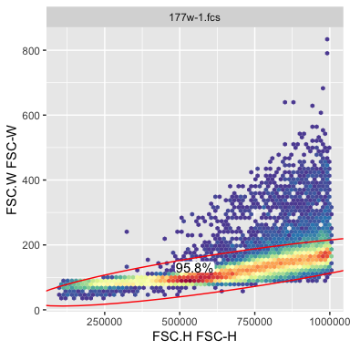

```r
ggcyto(ex, aes(x = FSC.H, y = FSC.W)) + geom_hex(bins = 64) + geom_gate(singlet.gate) + geom_stats()
```

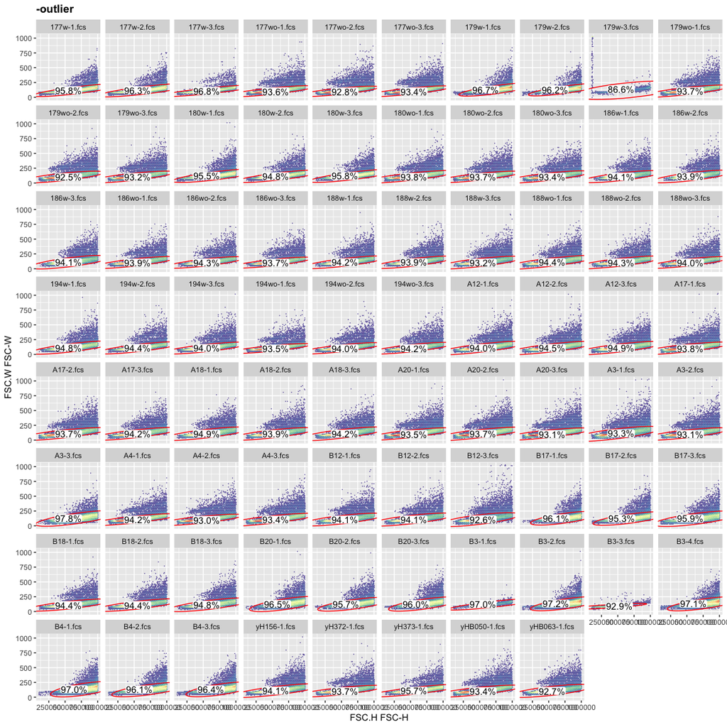

```r
ggcyto(gs, aes(x = FSC.H, y = FSC.W), subset = "-outlier") + geom_hex(bins = 64) + geom_gate("singlet") + geom_stats() +
  facet_wrap(~name, ncol = 10)# + scale_x_logicle() + scale_y_logicle()
```

### PHO5-mCherry induction

When I plotted the singlet events on GFP-RFP 2d space, I noticed a few samples that show more than one population of cells, where the main population appeared to be “induced” while one or more subpopulations are less or not induced. While the biological reasons behind require further investigation and may be very interesting (heterogeneity), for this analysis we will use flowClust to identify the main population and move forward.

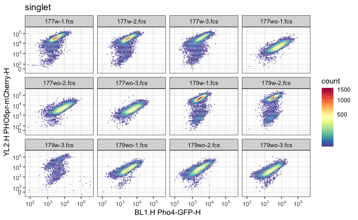

```r
ggcyto(gs[grepl("177|179", sampleNames(gs))], aes(x = BL1.H, y = YL2.H), subset = "singlet") + geom_hex(bins = 64) +
  facet_wrap(~name, ncol = 4) + scale_x_logicle() + scale_y_logicle() + theme_bw()
```

> Be careful when working with the GatingSet and GatingHierarchy objects – these are strictly reference classes, meaning that most of the operations work by pointers and the operations will change the underlying data. For example, the first line of code below obtains a pointer to the underlying data rather than making a copy of that data. any operations on it will change the original data as a result.

```r
#ex <- gs_pop_get_data(gs, "singlet")[[1]]
ex <- fs[["B3-1.fcs"]]
#lgcl <- estimateLogicle(ex, channels = c("BL1.H", "YL2.H"))
lgcl <- logicleTransform("induction")
ex <- transform(ex, lgBL1.H = lgcl(`BL1.H`), lgYL2.H = lgcl(`YL2.H`))
fluo.gate <- gate_flowclust_2d(ex, "lgBL1.H", "lgYL2.H", K = 2, quantile = 0.98)
```

```
The prior specification has no effect when usePrior=no
Using the serial version of flowClust
```

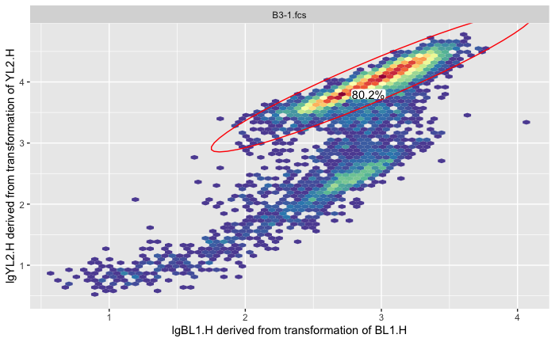

```r
ggcyto(ex, aes(x = lgBL1.H, y = lgYL2.H)) + geom_hex(bins = 64) + geom_gate(fluo.gate) + geom_stats()# + scale_x_logicle() + scale_y_logicle()
```

Even though flowClust is supposed to perform its own transformation (modified Box-Cox), empirically I found the clustering seem to work better on logicle transformed data for the two fluorescent channels. Therefore I’m transforming the underlying data of the GatingSet. Note that it seems to be difficult to “create new parameters” to store the transformed data, while keeping the original data intact. Instead, the transformation functions constructed using the constructor `logicle_trans()` stores the inverse transformation functions, which can be used to perform the inverse transformation when needed. Followed the manual for GatingSet [here](https://www.bioconductor.org/packages/devel/bioc/vignettes/flowWorkspace/inst/doc/flowWorkspace-Introduction.html#03_GatingHierarchy)

```r
lgcl <- logicle_trans()
transList <- transformerList(c(lgBL1.H = "BL1.H", lgclYL2.H = "YL2.H"), lgcl)
transform(gs, transList)
```

```
A GatingSet with 78 samples
```

> to obtain the original data, use `gs_pop_get_data(gs[[1]], inverse.transform = TRUE)`

Now we can do the flowClust gating

```r
dat <- gs_pop_get_data(gs, "singlet") # get parent data
inductionGate <- fsApply(dat, function(fr)
  openCyto::gate_flowclust_2d(fr, "BL1.H", "YL2.H", K = 2, quantile = 0.95)
)
```

[output not shown]

[output cut: 101 more lines]

[output not shown]

```r
gs_pop_add(gs, inductionGate, parent = "singlet", name = "induction")
```

```
[1] 4
```

```r
recompute(gs)
```

```
done!
```

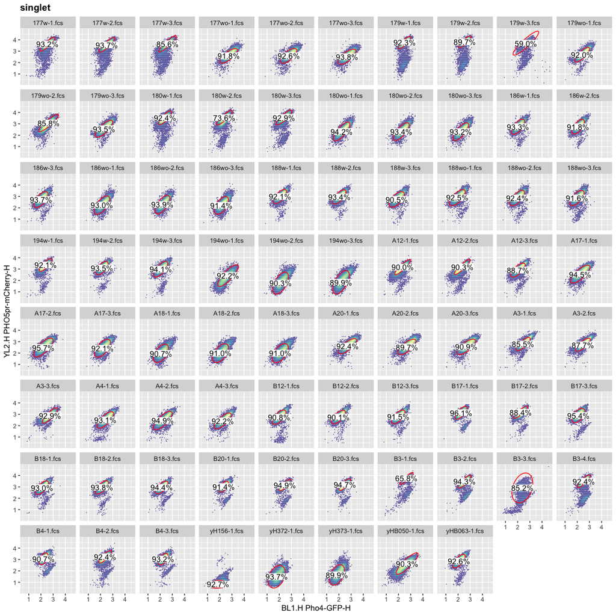

```r
ggcyto(gs, aes(x = BL1.H, y = YL2.H), subset = "singlet") + geom_hex(bins = 64) + geom_gate("induction") + geom_stats() +
  facet_wrap(~name, ncol = 10)# + scale_x_logicle() + scale_y_logicle()
```